# Assignment 3

Jordan Dever

2024-02-26

## 13.

```r
weekly = ISLR2::Weekly
```

Loading data from ISLR2 package, then producing some numerical and graphical summaries of the data.

```r
summary(weekly)
```

```
##       Year           Lag1               Lag2               Lag3
##  Min.   :1990   Min.   :-18.1950   Min.   :-18.1950   Min.   :-18.1950
##  1st Qu.:1995   1st Qu.: -1.1540   1st Qu.: -1.1540   1st Qu.: -1.1580
##  Median :2000   Median :  0.2410   Median :  0.2410   Median :  0.2410
##  Mean   :2000   Mean   :  0.1506   Mean   :  0.1511   Mean   :  0.1472
##  3rd Qu.:2005   3rd Qu.:  1.4050   3rd Qu.:  1.4090   3rd Qu.:  1.4090
##  Max.   :2010   Max.   : 12.0260   Max.   : 12.0260   Max.   : 12.0260
##       Lag4               Lag5              Volume            Today
##  Min.   :-18.1950   Min.   :-18.1950   Min.   :0.08747   Min.   :-18.1950
##  1st Qu.: -1.1580   1st Qu.: -1.1660   1st Qu.:0.33202   1st Qu.: -1.1540
##  Median :  0.2380   Median :  0.2340   Median :1.00268   Median :  0.2410
##  Mean   :  0.1458   Mean   :  0.1399   Mean   :1.57462   Mean   :  0.1499
##  3rd Qu.:  1.4090   3rd Qu.:  1.4050   3rd Qu.:2.05373   3rd Qu.:  1.4050
##  Max.   : 12.0260   Max.   : 12.0260   Max.   :9.32821   Max.   : 12.0260
##  Direction
##  Down:484
##  Up  :605
##
##
##
##
```

```r
str(weekly)
```

```
## 'data.frame':    1089 obs. of  9 variables:
##  $ Year     : num  1990 1990 1990 1990 1990 1990 1990 1990 1990 1990 ...
##  $ Lag1     : num  0.816 -0.27 -2.576 3.514 0.712 ...
##  $ Lag2     : num  1.572 0.816 -0.27 -2.576 3.514 ...
##  $ Lag3     : num  -3.936 1.572 0.816 -0.27 -2.576 ...
##  $ Lag4     : num  -0.229 -3.936 1.572 0.816 -0.27 ...
##  $ Lag5     : num  -3.484 -0.229 -3.936 1.572 0.816 ...
##  $ Volume   : num  0.155 0.149 0.16 0.162 0.154 ...
##  $ Today    : num  -0.27 -2.576 3.514 0.712 1.178 ...
##  $ Direction: Factor w/ 2 levels "Down","Up": 1 1 2 2 2 1 2 2 2 1 ...
```

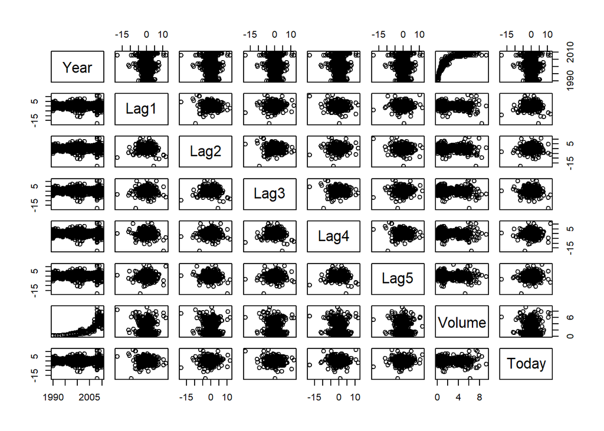

```r
weekly_corr = weekly %>%
  dplyr::select(-Direction) #removing direction from the plot

plot(weekly_corr)
```

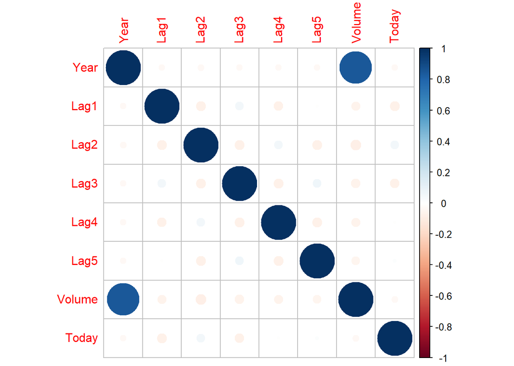

```r
corrplot::corrplot(cor(weekly_corr))
```

Looking at the numbers and graphs, it looks like the Lags all very similar ranges of data (-18:12 approx) along with all variables being numeric except our target variable of Direction. Direction is also semi-balanced with a 484:605 ratio. In the correlation plot, we can see a strong positive relationship between Volume and Year.

2. Time to fit a logistic regression on the data.

```r
weekly_glm = glm(Direction~Lag1+Lag2+Lag3+Lag4+Lag5+Volume, data = weekly,
                 family = binomial)
summary(weekly_glm)
```

```
##
## Call:
## glm(formula = Direction ~ Lag1 + Lag2 + Lag3 + Lag4 + Lag5 +
##     Volume, family = binomial, data = weekly)
##
## Coefficients:
##             Estimate Std. Error z value Pr(>|z|)
## (Intercept)  0.26686    0.08593   3.106   0.0019 **
## Lag1        -0.04127    0.02641  -1.563   0.1181
## Lag2         0.05844    0.02686   2.175   0.0296 *
## Lag3        -0.01606    0.02666  -0.602   0.5469
## Lag4        -0.02779    0.02646  -1.050   0.2937
## Lag5        -0.01447    0.02638  -0.549   0.5833
## Volume      -0.02274    0.03690  -0.616   0.5377
## ---
## Signif. codes:  0 '***' 0.001 '**' 0.01 '*' 0.05 '.' 0.1 ' ' 1
##
## (Dispersion parameter for binomial family taken to be 1)
##
##     Null deviance: 1496.2  on 1088  degrees of freedom
## Residual deviance: 1486.4  on 1082  degrees of freedom
## AIC: 1500.4
##
## Number of Fisher Scoring iterations: 4
```

Using an alpha level of 0.05, Lag2 is significant at a p-value of 0.0296.

3. Time to make the confusion martrix to assess accuracy.

```r
pred1 = predict(weekly_glm, type = 'response') > 0.5

tab1 <- table(Predicted = pred1, Actual = weekly$Direction)
tab1
```

```
##          Actual
## Predicted Down  Up
##     FALSE   54  48
##     TRUE   430 557
```

```r
sum(diag(tab1))/sum(tab1)
```

```
## [1] 0.5610652
```

We get an accuracy of 0.561 for this logistic regression model which isn’t all that great. Another issue with this is that the model is predicting a lot of False Negatives for Down. So the model predicts downtrends instead as uptrends.

4. Now only using Lag2 and train/test split based on years.

```r
weekly_train = weekly$Year < 2009

weekly_glm2 = glm(Direction~Lag2, data = weekly[weekly_train,], family = binomial)
summary(weekly_glm2)
```

```
##
## Call:
## glm(formula = Direction ~ Lag2, family = binomial, data = weekly[weekly_train,
##     ])
##
## Coefficients:
##             Estimate Std. Error z value Pr(>|z|)
## (Intercept)  0.20326    0.06428   3.162  0.00157 **
## Lag2         0.05810    0.02870   2.024  0.04298 *
## ---
## Signif. codes:  0 '***' 0.001 '**' 0.01 '*' 0.05 '.' 0.1 ' ' 1
##
## (Dispersion parameter for binomial family taken to be 1)
##
##     Null deviance: 1354.7  on 984  degrees of freedom
## Residual deviance: 1350.5  on 983  degrees of freedom
## AIC: 1354.5
##
## Number of Fisher Scoring iterations: 4
```

```r
pred2 = predict(weekly_glm2, weekly[!weekly_train, ], type = 'response') > 0.5

tab2 <- table(Predicted = pred2, Actual = weekly[!weekly_train,]$Direction)
tab2
```

```
##          Actual
## Predicted Down Up
##     FALSE    9  5
##     TRUE    34 56
```

```r
sum(diag(tab2))/sum(tab2)
```

```
## [1] 0.625
```

We get an accuracy of 0.625 of accurately predicting weekly trends on the final 2 test years. This is about an ~11% increase in accuracy compared to the previous model with multiple predictors and without a test split.

5. LDA

```r
weekly_lda = lda(Direction~Lag2, data = weekly[weekly_train,])

pred3 = predict(weekly_lda, weekly[!weekly_train, ], type = 'response')$class

tab3 <- table(Predicted = pred3, Actual = weekly[!weekly_train,]$Direction)
tab3
```

```
##          Actual
## Predicted Down Up
##      Down    9  5
##      Up     34 56
```

```r
sum(diag(tab3))/sum(tab3)
```

```
## [1] 0.625
```

LDA also had an accuracy of 0.625

6. QDA

```r
weekly_qda = qda(Direction~Lag2, data = weekly[weekly_train,])

pred4 = predict(weekly_qda, weekly[!weekly_train, ], type = 'response')$class

tab4 <- table(Predicted = pred4, Actual = weekly[!weekly_train,]$Direction)
tab4
```

```
##          Actual
## Predicted Down Up
##      Down    0  0
##      Up     43 61
```

```r
sum(diag(tab4))/sum(tab4)
```

```
## [1] 0.5865385
```

QDA accuracy : 0.587

7. KNN w/ K=1

```r
set.seed(1)
weekly_knn = knn(weekly[weekly_train, 'Lag2', drop = F],
                 weekly[!weekly_train, 'Lag2', drop = F],
                 weekly$Direction[weekly_train])

tab5 <- table(weekly_knn, weekly[!weekly_train,]$Direction)
tab5
```

```
##
## weekly_knn Down Up
##       Down   21 30
##       Up     22 31
```

```r
sum(diag(tab5))/sum(tab5)
```

```
## [1] 0.5
```

KNN Accuracy is .5

8. naive Bayes

```r
weekly_bayes = naiveBayes(Direction~Lag2, data = weekly, subset = weekly_train)
pred6 = predict(weekly_bayes, weekly[!weekly_train,], type = 'class')
tab6 <- table(pred6, weekly[!weekly_train,]$Direction)
tab6
```

```
##
## pred6  Down Up
##   Down    0  0
##   Up     43 61
```

```r
sum(diag(tab6))/sum(tab6)
```

```
## [1] 0.5865385
```

Naive Bayes accuracy of 0.587

1. Which is best? The two models that gave the best accuracies are LDA and Logistic Regression with 0.625 (after we only used Lag2 as a predictor).
10. Experiment

```r
weekly_lda = lda(Direction~Lag2+Volume, data = weekly[weekly_train,])

pred = predict(weekly_lda, weekly[!weekly_train, ], type = 'response')$class

tab <- table(Predicted = pred, Actual = weekly[!weekly_train,]$Direction)
tab
```

```
##          Actual
## Predicted Down Up
##      Down   20 25
##      Up     23 36
```

```r
sum(diag(tab))/sum(tab)
```

```
## [1] 0.5384615
```

Only adding Volume changed the accuracy by almost 0.1!

```r
set.seed(1)
weekly_knn = knn(weekly[weekly_train, 'Lag2', drop = F],
                 weekly[!weekly_train, 'Lag2', drop = F],
                 weekly$Direction[weekly_train], k =10)

tab <- table(weekly_knn, weekly[!weekly_train,]$Direction)
tab
```

```
##
## weekly_knn Down Up
##       Down   17 21
##       Up     26 40
```

```r
sum(diag(tab))/sum(tab)
```

```
## [1] 0.5480769
```

Increasing k to 10 gave us 0.048 increased accuracy.

## 14.

```r
auto = ISLR2::Auto
mpg01 = rep(0, length(auto$mpg))
mpg01[auto$mpg > median(auto$mpg)] = 1
auto = data.frame(auto, mpg01)
summary(auto$mpg)
```

```
##    Min. 1st Qu.  Median    Mean 3rd Qu.    Max.
##    9.00   17.00   22.75   23.45   29.00   46.60
```

```r
view(auto)
```

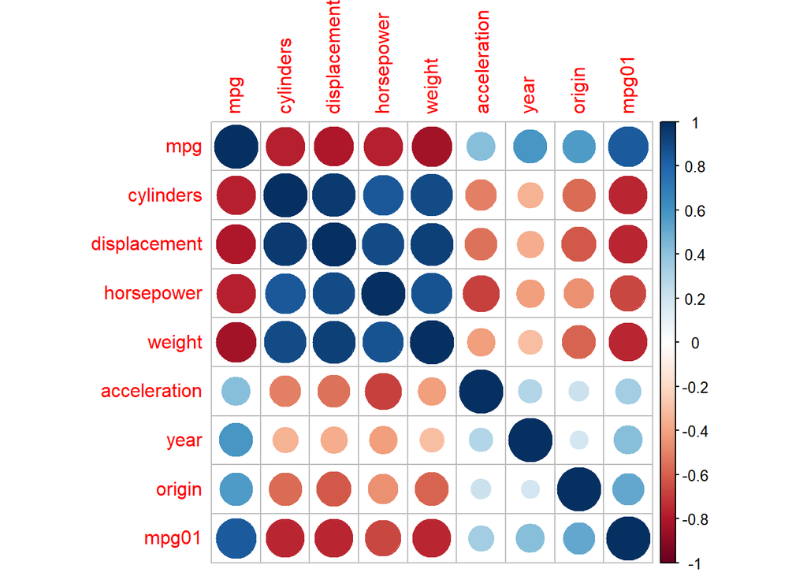

```r
auto_no_name = auto %>%
  dplyr::select(-name)
corrplot::corrplot(cor(auto_no_name))
```

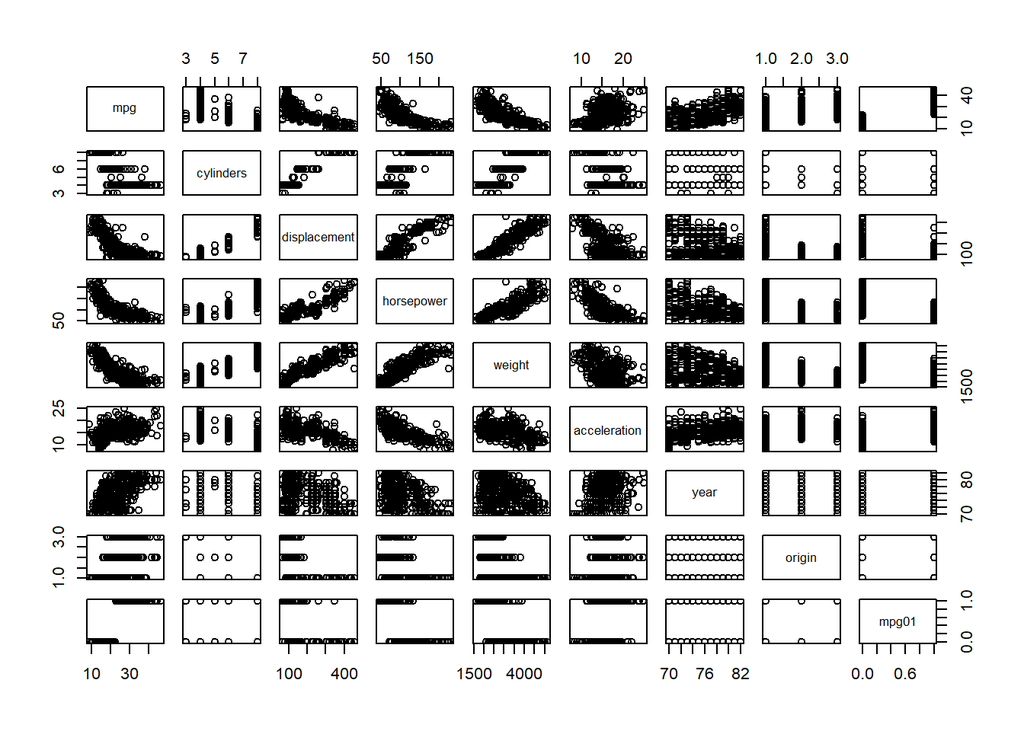

```r
plot(auto_no_name)
```

Variables that are positively correlated: mpg, and slight correlation with origin Negatively correlated: Cylinders, Displacement, Horsepower, Weight

3. Test/Train Split

```r
set.seed(1)
index = sample(1:nrow(auto), 0.8*nrow(auto))
auto_train = auto[index,]
auto_test = auto[-index,]
```

4. LDA I will use cylinders, displacement,horsepower, and weight because they looked to have the largest association with mpg01.

```r
auto_lda = lda(mpg01~ cylinders + displacement + weight+ horsepower,
               data = auto_train)
pred = predict(auto_lda, auto_test)
tab = table(pred$class, auto_test$mpg01)
tab
```

```
##
##      0  1
##   0 35  0
##   1  7 37
```

```r
sum(diag(tab))/sum(tab)
```

```
## [1] 0.9113924
```

```r
mean(pred$class != auto_test$mpg01)
```

```
## [1] 0.08860759
```

This LDA model using an 80/20 train/test split got an accuracy of 91.1% or an error rate of 8.8%.

5. QDA

```r
auto_qda = qda(mpg01~ cylinders + displacement + weight + horsepower,
               data = auto_train)
pred = predict(auto_qda, auto_test)
tab = table(pred$class, auto_test$mpg01)
tab
```

```
##
##      0  1
##   0 37  2
##   1  5 35
```

```r
sum(diag(tab))/sum(tab)
```

```
## [1] 0.9113924
```

```r
mean(pred$class != auto_test$mpg01)
```

```
## [1] 0.08860759
```

Same accuracy / error rate as the LDA 91.1% acc, 8.8% error

6. logistic regression

```r
auto_glm = glm(mpg01~ cylinders + displacement + weight + horsepower,
               data = auto_train, family = binomial())
pred = predict(auto_glm, auto_test, type = 'response') > 0.5
tab = table(Predicted = pred, Actual = auto_test$mpg01)
tab
```

```
##          Actual
## Predicted  0  1
##     FALSE 38  1
##     TRUE   4 36
```

```r
sum(diag(tab))/sum(tab)
```

```
## [1] 0.9367089
```

```r
1 - (sum(diag(tab))/sum(tab))
```

```
## [1] 0.06329114
```

Logistic regression gave us an accuracy of 93.7% and an error rate of 6.3% which is better than our prior models.

7. Naive Bayes

```r
auto_bayes = naiveBayes(mpg01 ~ cylinders + displacement + weight + horsepower,
               data = auto_train)
pred = predict(auto_bayes, auto_test, type = 'class')
tab = table(Predicted = pred, Actual = auto_test$mpg01)
tab
```

```
##          Actual
## Predicted  0  1
##         0 37  1
##         1  5 36
```

```r
sum(diag(tab))/sum(tab)
```

```
## [1] 0.9240506
```

```r
1 - (sum(diag(tab))/sum(tab))
```

```
## [1] 0.07594937
```

Bayes gave us an accuracy of 92.4% and error of 7.6%

8. KNN

```r
set.seed(1)
auto_train = auto[index,c(2, 3, 4, 5)]
auto_test <- auto[-index, c(2, 3, 4, 5)]
auto_knn <- knn(auto_train, auto_test, auto$mpg01[index], k = 1)

tab <- table(auto_knn, auto$mpg01[-index])
accuracy <- sum(diag(tab)) / sum(tab)
tab
```

```
##
## auto_knn  0  1
##        0 36  4
##        1  6 33
```

```r
accuracy
```

```
## [1] 0.8734177
```

```r
1-accuracy
```

```
## [1] 0.1265823
```

```r
set.seed(1)
finding_k = sapply(1:10, function(i) {
  auto_knn = knn(auto_train, auto_test, auto$mpg01[index], k = i)
  mean(auto_knn != auto$mpg01[-index])
})
names(finding_k) = 1:10
finding_k[which.min(finding_k)]
```

```
##          6
## 0.07594937
```

The best k=6 which gave us an accuracy of 92.4% and an error of 7.6% which is better than k=1 which gave us 87.3% accuracy and 12.75 error

## 16.

```r
boston = ISLR2::Boston
morecrim = rep(0, length(boston$crim))
morecrim[boston$crim > median(boston$crim)] = 1
boston = data.frame(boston, morecrim)
summary(boston)
```

```
##       crim                zn             indus            chas
##  Min.   : 0.00632   Min.   :  0.00   Min.   : 0.46   Min.   :0.00000
##  1st Qu.: 0.08205   1st Qu.:  0.00   1st Qu.: 5.19   1st Qu.:0.00000
##  Median : 0.25651   Median :  0.00   Median : 9.69   Median :0.00000
##  Mean   : 3.61352   Mean   : 11.36   Mean   :11.14   Mean   :0.06917
##  3rd Qu.: 3.67708   3rd Qu.: 12.50   3rd Qu.:18.10   3rd Qu.:0.00000
##  Max.   :88.97620   Max.   :100.00   Max.   :27.74   Max.   :1.00000
##       nox               rm             age              dis
##  Min.   :0.3850   Min.   :3.561   Min.   :  2.90   Min.   : 1.130
##  1st Qu.:0.4490   1st Qu.:5.886   1st Qu.: 45.02   1st Qu.: 2.100
##  Median :0.5380   Median :6.208   Median : 77.50   Median : 3.207
##  Mean   :0.5547   Mean   :6.285   Mean   : 68.57   Mean   : 3.795
##  3rd Qu.:0.6240   3rd Qu.:6.623   3rd Qu.: 94.08   3rd Qu.: 5.188
##  Max.   :0.8710   Max.   :8.780   Max.   :100.00   Max.   :12.127
##       rad              tax           ptratio          lstat
##  Min.   : 1.000   Min.   :187.0   Min.   :12.60   Min.   : 1.73
##  1st Qu.: 4.000   1st Qu.:279.0   1st Qu.:17.40   1st Qu.: 6.95
##  Median : 5.000   Median :330.0   Median :19.05   Median :11.36
##  Mean   : 9.549   Mean   :408.2   Mean   :18.46   Mean   :12.65
##  3rd Qu.:24.000   3rd Qu.:666.0   3rd Qu.:20.20   3rd Qu.:16.95
##  Max.   :24.000   Max.   :711.0   Max.   :22.00   Max.   :37.97
##       medv          morecrim
##  Min.   : 5.00   Min.   :0.0
##  1st Qu.:17.02   1st Qu.:0.0
##  Median :21.20   Median :0.5
##  Mean   :22.53   Mean   :0.5
##  3rd Qu.:25.00   3rd Qu.:1.0
##  Max.   :50.00   Max.   :1.0
```

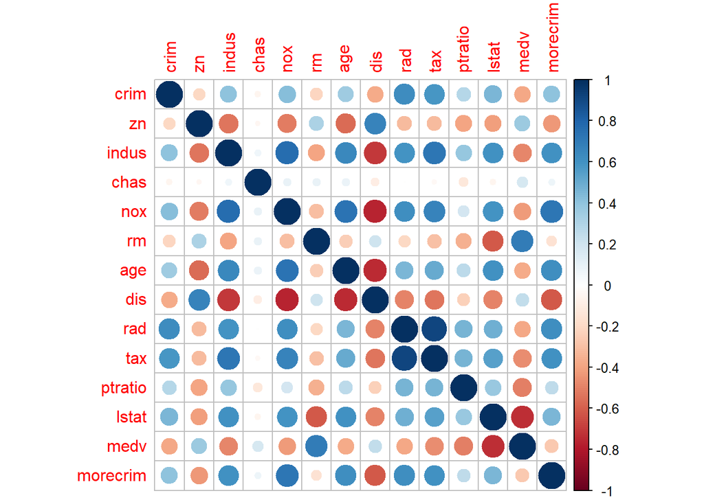

```r
corrplot::corrplot(cor(boston))
```

Potential predictors based on larger circles on morecrim in the correlation plot: indus, nox, age, dis, rad, tax

```r
set.seed(1)
index = sample(1:nrow(auto), 0.8*nrow(auto))
boston_train = boston[index,]
boston_test = boston[-index,]
```

Logit

```r
boston_glm = glm(morecrim ~ indus+ nox+ age+ dis+ rad+ tax, data = boston_train,
                 family = binomial)
pred = predict(boston_glm, boston_test, type = 'response') > 0.5
tab = table(Predicted = pred, Actual = boston_test$morecrim)
tab
```

```
##          Actual
## Predicted   0   1
##     FALSE  52   4
##     TRUE   13 124
```

```r
sum(diag(tab))/sum(tab)
```

```
## [1] 0.9119171
```

```r
1 - (sum(diag(tab))/sum(tab))
```

```
## [1] 0.0880829
```

Logistic regression accuracy: 91.2% Error: 8.8%

LDA

```r
boston_lda = lda(morecrim ~ indus+ nox+ age+ dis+ rad+ tax, data = boston_train)
pred = predict(boston_lda, boston_test)
tab = table(pred$class, boston_test$morecrim)
tab
```

```
##
##       0   1
##   0  49  11
##   1  16 117
```

```r
sum(diag(tab))/sum(tab)
```

```
## [1] 0.8601036
```

```r
mean(pred$class != boston_test$morecrim)
```

```
## [1] 0.1398964
```

LDA Acc: 86% Error: 14%

Naive Bayes

```r
boston_bayes = naiveBayes(morecrim ~ indus+ nox+ age+ dis+ rad+ tax,
                           data = boston_train)
pred = predict(boston_bayes, boston_test, type = 'class')
tab <- table(pred, boston_test$morecrim)
tab
```

```
##
## pred   0   1
##    0  47  12
##    1  18 116
```

```r
sum(diag(tab))/sum(tab)
```

```
## [1] 0.8445596
```

```r
1-(sum(diag(tab))/sum(tab))
```

```
## [1] 0.1554404
```

Naive Bayes Acc: 84.4% Error: 15.5%

KNN

```r
set.seed(1)
boston_train = boston[index,c(3,5,7,8,9,10)]
boston_test = boston[-index, c(3,5,7,8,9,10)]
boston_knn = knn(boston_train, boston_test, boston$morecrim[index], k = 1)

tab = table(boston_knn, boston$morecrim[-index])
accuracy = sum(diag(tab)) / sum(tab)
tab
```

```
##
## boston_knn   0   1
##          0  54   6
##          1  11 122
```

```r
accuracy
```

```
## [1] 0.9119171
```

```r
1-accuracy
```

```
## [1] 0.0880829
```

With k=1, Acc: 91.2% Error: 8.8% Time to do a for loop to find best k.

```r
set.seed(1)
finding_k = sapply(1:30, function(i) {
  boston_knn = knn(boston_train, boston_test, boston$morecrim[index], k = i)
  mean(boston_knn != boston$morecrim[-index])
})
names(finding_k) = 1:10
finding_k[which.min(finding_k)]
```

```
##          3
## 0.08290155
```

```r
set.seed(1)
boston_train = boston[index,c(3,5,7,8,9,10)]
boston_test = boston[-index, c(3,5,7,8,9,10)]
boston_knn = knn(boston_train, boston_test, boston$morecrim[index], k = 3)

tab = table(boston_knn, boston$morecrim[-index])
accuracy = sum(diag(tab)) / sum(tab)
tab
```

```
##
## boston_knn   0   1
##          0  56   7
##          1   9 121
```

```r
accuracy
```

```
## [1] 0.9170984
```

```r
1-accuracy
```

```
## [1] 0.08290155
```

Best k=3, so we got a slightly improved accuracy of 91.7 and a lower error rate of 8.3%.

The best model we got for the Boston data was the final KNN model where k=3 with an accuracy of 91.7 and error rate of 8.3%. The next best models were the logistic regression and KNN=1 with both having an accuracy of 91.2%.